# HW_2

In order to compare the schools we have to compute the rows , producing a frequency distribution. Eeach cell have to be devided to the corresponding row sum. With this standartization we can compare them based on a distribution ratio.

```r
# dividing each value by the row sum
aggregate.avg = aggregate[,2:length(aggregate)]/rowSums(aggregate[,2:length(aggregate)])
aggregate.avg$School = aggregate$School
aggregate.avg
```

```
##     Middling    Behind More_Behind Very_Behind Completed School
## 1 0.12124464 0.4828326  0.07832618  0.16523605 0.1523605      A
## 2 0.18834081 0.4506726  0.03139013  0.04932735 0.2802691      B
## 3 0.12941176 0.4588235  0.04705882  0.14117647 0.2235294      C
## 4 0.13636364 0.3636364  0.09090909  0.27272727 0.1363636      D
## 5 0.09482759 0.4827586  0.06034483  0.12931034 0.2327586      E
```

In order to visualize the data, we need to melt it - transform it from wide to long syntax.

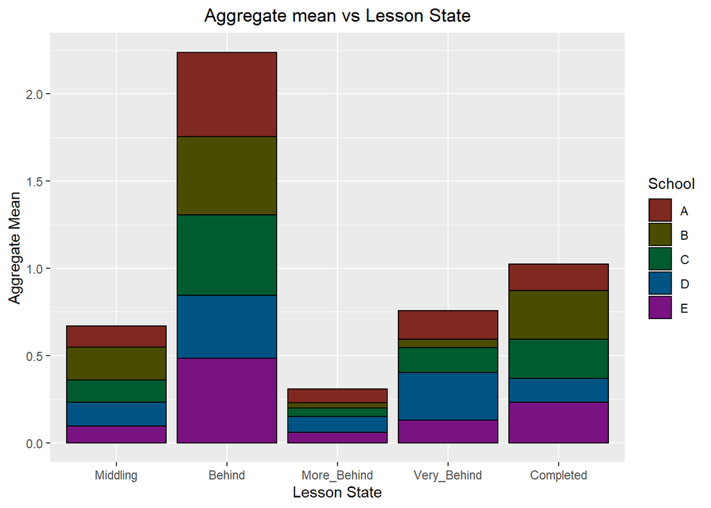

```r
# melt dataset to a long format
aggregate.m = melt(aggregate.avg, id = 'School')
# generating stack bars
stack_bar <- ggplot(aggregate.m)+
  geom_bar(stat = 'summary', fun.y ='mean', color ='black', aes(x=variable, y=value, fill=School))+ labs(x = 'Lesson State', y = 'Aggregate Mean', title = 'Aggregate mean vs Lesson State', fill = 'School')+ theme(plot.title = element_text(hjust = 0.5))+ scale_fill_hue(l=30,c=65)
stack_bar
```

We can notice again the general pattern. Students that are behind are the most in all schools. Completed, Very behind and Middling are close to each other. There always can be issues with the data set too. In some cases it can not be fully representative of the School it was gathered.

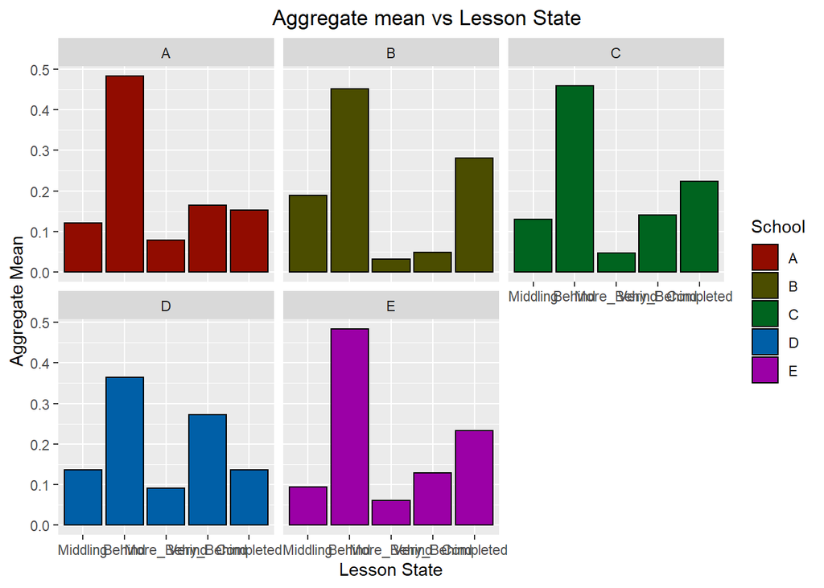

```r
# separate bar charts
line_graphs <- ggplot(aggregate.m)+
  geom_bar(stat = 'summary', fun.y ='mean', color='black', aes(x=variable, y=value, fill=School))+ facet_wrap(~School) + labs(x = 'Lesson State', y = 'Aggregate Mean', title = 'Aggregate mean vs Lesson State', fill = 'School')+ theme(plot.title = element_text(hjust = 0.6))+scale_fill_hue(l=30)
line_graphs
```

[output not shown]